# Techniques de régularisation : Ridge et Lasso

## Introduction

Supposons que nous voulons estimer le prix des appartements en fonction de plusieurs variables ( surfaces, localisation, modernité…). On observe le résultat suivant :

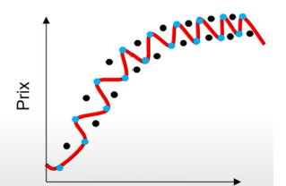

On obtient un modèle(en rouge) qui s’adapte fortement aux donnés d’entraînement (point en bleu) mais pas aux données de tests (en noir) : C’est le sur-apprentissage (overfitting) , un évènement craint dans le milieu de la Data Science ! Mais, pas de panique, il existe plusieurs méthodes qui permettent de résoudre ce problème dont les méthodes de régularisation que nous allons aborder aujourd’hui.

Ces techniques sont des évolutions de la régression linéaire qui s’adaptatent au “Wide data” (nombre important de variables supérieur au nombre d’individus) et aux variables corrélées. Elles vont introduire un paramètre $\lambda \geq 0$ dans la fonction coût pour la pénaliser, c’est à dire réduire la valeur des estimateurs pour limiter la complexité du modèle et donc limiter le risque sur-apprentissage . La fonction coût devient alors:
$$J = \frac{1}{2n} * \sum_{i=1}^{n}
[{({\hat{y}}_{i}-y_{i})}^{2} + \color{red}{\lambda*g(\beta)}]$$
$n: nombre\; d'individus$, $g(\beta):une \;fonction \;dépendant \; des\; estimateurs$, $y_i : la\; variable\; cible\; pour \;l'observation\;i$ ,${\hat{y}_{i}} :prédiction\; pour\; l'observation\;i \;avec\; l'estimateur\; des\; moindres \;carrés$.

A l’aide d’une application sur R, nous allons étudier deux régressions pénalisées bien connues : Ridge et lasso. Nous essayerons de comprendre leur fonctionnement, d’observer leurs différences et de voir comment les optimiser.

## 1 : La régression Lasso ou la pénalité L1

La régression lasso permet de concevoir un modèle plus simple avec moins de variables pour éviter le sur-apprentissage. Le paramètre de pénalité va réduire à zéro tous les estimateurs des variables ayant moins d’importance pour le modèle et ne garder que celles qui sont utiles. Sa fonction de coût est la suivante :
$$J = \frac{1}{2n} *[ \sum_{i=1}^{n}
{({\hat{y}}^{(i)}-y^{i})}^{2} + \lambda*\sum_{j=1}^{p}|{\beta}_j|
\:]$$
L’un des cas d’usage préféré de cette régression est lorsque le nombre de variables est plus important que le nombre d’individus. Dans cette situation,nous avons une matrice explicative $X_{n,p}$ avec n<p, la matrice d’information $X^{T}X$ devient donc non-inversible, ce qui pose un problème pour le calcul des coefficients avec les estimateurs de moindre carré classique.

## 2: La régression Ridge ou la pénalité L2

Sa fonction coût est la suivante :
$$J = \frac{1}{2n} *[ \sum_{i=1}^{n}
{({\hat{y}}^{(i)}-y^{i})}^{2} + \lambda*\sum_{j=1}^{p}{{\beta}_j}^{2}
\:]$$
Ici, nous avons ${{\beta}_{j}}^2$ au lieu des $|{\beta}_{j}|$ de la régression Lasso. L’objectif de la ridge est de réduire les valeurs des estimateurs tout en les rendant homogènes. Homogénéiser les estimateurs ou les mettre à la même échelle permettra que les effets des variables trop importantes ne masquent pas l’effet de celles moins importantes, ce qui va réduire la variance du modèle. Cette régression est utilisée très souvent lorsqu’on a des variables corrélées.

## 3 : Comment choisir le paramètre $\color{red} \lambda$ ?

Si vous avez bien suivi jusque là, les fonctions de coût des regressions Lasso et Ridge vont dépendre d’un paramètre $\lambda$ qui va influencer le modèle en fonction de sa valeur.

Lorsque $\lambda$ tend vers zéro, on se rapproche du modèle linéaire simple et donc la régularisation n’aura pas d’importance. Si $\lambda$ est grand,les valeurs des estimateurs seront réduites mais pas l’erreur de prédiction du modèle.

Pour Lasso, une valeur forte de λ va réduire plusieurs estimateurs à zéro tandis que pour la régression Ridge, les valeurs seront faibles mais pas égales à zéro.

Dans les applications R, comme nous allons le voir, le paramètre λ est choisie grâce à la cross validation.

Finie les théories, passons maintenant à la pratique.

## 4 : Application

### Importation des librairies

```r
library(mltools)
library(data.table)
library(glmnet)
library(magrittr)
library(dplyr)
library(highcharter)
library(Metrics)
library(knitr)
```

### 4.1 : Présentation des données

Nous disposons d’un jeu de données qui contient différents caractéristiques de maisons aux Etats-unis. Le but est de prédire le prix de ces maisons en fonction des nombreuses caractéristiques en utilisant les régression Lasso et Ridge. Si vous souhaitez avoir la description complète du jeu de données, cliquez [ici](https://www.kaggle.com/competitions/house-prices-advanced-regression-techniques/data?select=data_description.txt) .

### 4.2 Importation des données

```r
data <- read.csv("train.csv")
print("Voici les six premières lignes de notre jeu de donnés")
```

```
## [1] "Voici les six premières lignes de notre jeu de donnés"
```

```r
kable(head(data))
```

| Id | MSSubClass | MSZoning | LotFrontage | LotArea | Street | Alley | LotShape | LandContour | Utilities | LotConfig | LandSlope | Neighborhood | Condition1 | Condition2 | BldgType | HouseStyle | OverallQual | OverallCond | YearBuilt | YearRemodAdd | RoofStyle | RoofMatl | Exterior1st | Exterior2nd | MasVnrType | MasVnrArea | ExterQual | ExterCond | Foundation | … |
| --- | --- | --- | --- | --- | --- | --- | --- | --- | --- | --- | --- | --- | --- | --- | --- | --- | --- | --- | --- | --- | --- | --- | --- | --- | --- | --- | --- | --- | --- | --- |
| 1 | 60 | RL | 65 | 8450 | Pave | NA | Reg | Lvl | AllPub | Inside | Gtl | CollgCr | Norm | Norm | 1Fam | 2Story | 7 | 5 | 2003 | 2003 | Gable | CompShg | VinylSd | VinylSd | BrkFace | 196 | Gd | TA | PConc | … |
| 2 | 20 | RL | 80 | 9600 | Pave | NA | Reg | Lvl | AllPub | FR2 | Gtl | Veenker | Feedr | Norm | 1Fam | 1Story | 6 | 8 | 1976 | 1976 | Gable | CompShg | MetalSd | MetalSd | None | 0 | TA | TA | CBlock | … |
| 3 | 60 | RL | 68 | 11250 | Pave | NA | IR1 | Lvl | AllPub | Inside | Gtl | CollgCr | Norm | Norm | 1Fam | 2Story | 7 | 5 | 2001 | 2002 | Gable | CompShg | VinylSd | VinylSd | BrkFace | 162 | Gd | TA | PConc | … |
| 4 | 70 | RL | 60 | 9550 | Pave | NA | IR1 | Lvl | AllPub | Corner | Gtl | Crawfor | Norm | Norm | 1Fam | 2Story | 7 | 5 | 1915 | 1970 | Gable | CompShg | Wd Sdng | Wd Shng | None | 0 | TA | TA | BrkTil | … |
| 5 | 60 | RL | 84 | 14260 | Pave | NA | IR1 | Lvl | AllPub | FR2 | Gtl | NoRidge | Norm | Norm | 1Fam | 2Story | 8 | 5 | 2000 | 2000 | Gable | CompShg | VinylSd | VinylSd | BrkFace | 350 | Gd | TA | PConc | … |
| 6 | 50 | RL | 85 | 14115 | Pave | NA | IR1 | Lvl | AllPub | Inside | Gtl | Mitchel | Norm | Norm | 1Fam | 1.5Fin | 5 | 5 | 1993 | 1995 | Gable | CompShg | VinylSd | VinylSd | None | 0 | TA | TA | Wood | … |

Nos données contiennent respectivement 1460 lignes et 81colonnes.

### 4.3 Nettoyage de données

#### *Recherche des variables avec valeurs manquantes*

```r
na_presence <-data.frame(sapply(data, function(x) sum(is.na(x))))
colnames(na_presence)='Nb_abs'
kable(head(na_presence))
```

|  | Nb_abs |
| --- | --- |
| Id | 0 |
| MSSubClass | 0 |
| MSZoning | 0 |
| LotFrontage | 259 |
| LotArea | 0 |
| Street | 0 |

#### *Recherche des variables dont le nombre de NA est supérieure à 10% de nos données.*

```r
na_presence$variables <- rownames(na_presence)
na_sup10<- na_presence$variables[na_presence$Nb_abs>0.10*dim(data)[1]]
na_sup10
```

```
## [1] "LotFrontage" "Alley"       "FireplaceQu" "PoolQC"      "Fence"
## [6] "MiscFeature"
```

#### *Suppression de ces variables*

```r
data <- data[,!names(data) %in% na_sup10]
kable(head(data))
```

| Id | MSSubClass | MSZoning | LotArea | Street | LotShape | LandContour | Utilities | LotConfig | LandSlope | Neighborhood | Condition1 | Condition2 | BldgType | HouseStyle | OverallQual | OverallCond | YearBuilt | YearRemodAdd | RoofStyle | RoofMatl | Exterior1st | Exterior2nd | MasVnrType | MasVnrArea | ExterQual | ExterCond | Foundation | BsmtQual | BsmtCond | … |
| --- | --- | --- | --- | --- | --- | --- | --- | --- | --- | --- | --- | --- | --- | --- | --- | --- | --- | --- | --- | --- | --- | --- | --- | --- | --- | --- | --- | --- | --- | --- |
| 1 | 60 | RL | 8450 | Pave | Reg | Lvl | AllPub | Inside | Gtl | CollgCr | Norm | Norm | 1Fam | 2Story | 7 | 5 | 2003 | 2003 | Gable | CompShg | VinylSd | VinylSd | BrkFace | 196 | Gd | TA | PConc | Gd | TA | … |
| 2 | 20 | RL | 9600 | Pave | Reg | Lvl | AllPub | FR2 | Gtl | Veenker | Feedr | Norm | 1Fam | 1Story | 6 | 8 | 1976 | 1976 | Gable | CompShg | MetalSd | MetalSd | None | 0 | TA | TA | CBlock | Gd | TA | … |
| 3 | 60 | RL | 11250 | Pave | IR1 | Lvl | AllPub | Inside | Gtl | CollgCr | Norm | Norm | 1Fam | 2Story | 7 | 5 | 2001 | 2002 | Gable | CompShg | VinylSd | VinylSd | BrkFace | 162 | Gd | TA | PConc | Gd | TA | … |
| 4 | 70 | RL | 9550 | Pave | IR1 | Lvl | AllPub | Corner | Gtl | Crawfor | Norm | Norm | 1Fam | 2Story | 7 | 5 | 1915 | 1970 | Gable | CompShg | Wd Sdng | Wd Shng | None | 0 | TA | TA | BrkTil | TA | Gd | … |
| 5 | 60 | RL | 14260 | Pave | IR1 | Lvl | AllPub | FR2 | Gtl | NoRidge | Norm | Norm | 1Fam | 2Story | 8 | 5 | 2000 | 2000 | Gable | CompShg | VinylSd | VinylSd | BrkFace | 350 | Gd | TA | PConc | Gd | TA | … |
| 6 | 50 | RL | 14115 | Pave | IR1 | Lvl | AllPub | Inside | Gtl | Mitchel | Norm | Norm | 1Fam | 1.5Fin | 5 | 5 | 1993 | 1995 | Gable | CompShg | VinylSd | VinylSd | None | 0 | TA | TA | Wood | Gd | TA | … |

Le nouveau nombre de colonnes est : 75

### 4.4 Encodage et découpage des données :

#### *Standardisation des variables numériques*

```r
# sélectionner les colonnes numériques
data_num = data %>% select_if(is.numeric)

# standardiser les colonnes numériques
data_scaled = as.data.frame(scale(data_num))

# sélectionner les colonnes non numériques
data_not_num = data %>% select_if(function(x) !is.numeric(x))

# réintégrer les colonnes standardisées dans le data frame original
data_scaled_and_not = cbind(data_scaled,data_not_num)
kable(head(data_scaled_and_not))
```

| Id | MSSubClass | LotArea | OverallQual | OverallCond | YearBuilt | YearRemodAdd | MasVnrArea | BsmtFinSF1 | BsmtFinSF2 | BsmtUnfSF | TotalBsmtSF | X1stFlrSF | X2ndFlrSF | LowQualFinSF | GrLivArea | BsmtFullBath | BsmtHalfBath | FullBath | HalfBath | BedroomAbvGr | KitchenAbvGr | TotRmsAbvGrd | Fireplaces | GarageYrBlt | GarageCars | GarageArea | WoodDeckSF | OpenPorchSF | EnclosedPorch | … |
| --- | --- | --- | --- | --- | --- | --- | --- | --- | --- | --- | --- | --- | --- | --- | --- | --- | --- | --- | --- | --- | --- | --- | --- | --- | --- | --- | --- | --- | --- | --- |
| -1.730272 | 0.0733498 | -0.2070708 | 0.6512561 | -0.5170227 | 1.0506338 | 0.8783671 | 0.5098397 | 0.5752277 | -0.288554 | -0.9442671 | -0.4591452 | -0.7931620 | 1.1614536 | -0.1202005 | 0.3702066 | 1.1074307 | -0.2409785 | 0.789470 | 1.2271649 | 0.163723 | -0.2113812 | 0.9118973 | -0.9509007 | 0.9920660 | 0.3116179 | 0.3508801 | -0.7519182 | 0.2164290 | -0.3592018 | … |
| -1.727900 | -0.8722639 | -0.0918549 | -0.0718115 | 2.1788812 | 0.1566800 | -0.4294298 | -0.5726373 | 1.1715907 | -0.288554 | -0.6410084 | 0.4663051 | 0.2570524 | -0.7948909 | -0.1202005 | -0.4823466 | -0.8196835 | 3.9474568 | 0.789470 | -0.7613598 | 0.163723 | -0.2113812 | -0.3185741 | 0.6002892 | -0.1015064 | 0.3116179 | -0.0607102 | 1.6256378 | -0.7042419 | -0.3592018 | … |
| -1.725528 | 0.0733498 | 0.0734548 | 0.6512561 | -0.5170227 | 0.9844150 | 0.8299302 | 0.3220631 | 0.0928754 | -0.288554 | -0.3015397 | -0.3132614 | -0.6276110 | 1.1889432 | -0.1202005 | 0.5148362 | 1.1074307 | -0.2409785 | 0.789470 | 1.2271649 | 0.163723 | -0.2113812 | -0.3185741 | 0.6002892 | 0.9110606 | 0.3116179 | 0.6315098 | -0.7519182 | -0.0703374 | -0.3592018 | … |
| -1.723156 | 0.3097533 | -0.0968643 | 0.6512561 | -0.5170227 | -1.8629933 | -0.7200514 | -0.5726373 | -0.4991026 | -0.288554 | -0.0616484 | -0.6870887 | -0.5215549 | 0.9369551 | -0.1202005 | 0.3835277 | 1.1074307 | -0.2409785 | -1.025689 | -0.7613598 | 0.163723 | -0.2113812 | 0.2966616 | 0.6002892 | 0.7895526 | 1.6497417 | 0.7905334 | -0.7519182 | -0.1759881 | 4.0911220 | … |
| -1.720785 | 0.0733498 | 0.3750198 | 1.3743237 | -0.5170227 | 0.9513056 | 0.7330564 | 1.3603573 | 0.4634097 | -0.288554 | -0.1748047 | 0.1996113 | -0.0455956 | 1.6173231 | -0.1202005 | 1.2988806 | 1.1074307 | -0.2409785 | 0.789470 | 1.2271649 | 1.389547 | -0.2113812 | 1.5271330 | 0.6002892 | 0.8705579 | 1.6497417 | 1.6979029 | 0.7799299 | 0.5635672 | -0.3592018 | … |
| -1.718413 | -0.1630536 | 0.3604926 | -0.7948791 | -0.5170227 | 0.7195398 | 0.4908717 | -0.5726373 | 0.6322330 | -0.288554 | -1.1388958 | -0.5959113 | -0.9483661 | 0.5017028 | -0.1202005 | -0.2920446 | 1.1074307 | -0.2409785 | -1.025689 | 1.2271649 | -2.287924 | -0.2113812 | -0.9338098 | -0.9509007 | 0.5870392 | 0.3116179 | 0.0328330 | -0.4327832 | -0.2514530 | -0.3592018 | … |

#### *Encodage des variables*

Nous allons encoder nos variables qualitatives grâce à la librairie mltools.

```r
data <- data_scaled_and_not
for (i in 1:dim(data)[2])
{
  if (class(data[,i]) == "character")
  {
    data[,i] <- factor(data[,i])
  }
}
data<- one_hot(as.data.table(data))
n <- dim(data)[1] # nombre de lignes
p <- dim(data) [2] # nombre de colonnes
kable(head(data))
```

| Id | MSSubClass | LotArea | OverallQual | OverallCond | YearBuilt | YearRemodAdd | MasVnrArea | BsmtFinSF1 | BsmtFinSF2 | BsmtUnfSF | TotalBsmtSF | X1stFlrSF | X2ndFlrSF | LowQualFinSF | GrLivArea | BsmtFullBath | BsmtHalfBath | FullBath | HalfBath | BedroomAbvGr | KitchenAbvGr | TotRmsAbvGrd | Fireplaces | GarageYrBlt | GarageCars | GarageArea | WoodDeckSF | OpenPorchSF | EnclosedPorch | … |
| --- | --- | --- | --- | --- | --- | --- | --- | --- | --- | --- | --- | --- | --- | --- | --- | --- | --- | --- | --- | --- | --- | --- | --- | --- | --- | --- | --- | --- | --- | --- |
| -1.730272 | 0.0733498 | -0.2070708 | 0.6512561 | -0.5170227 | 1.0506338 | 0.8783671 | 0.5098397 | 0.5752277 | -0.288554 | -0.9442671 | -0.4591452 | -0.7931620 | 1.1614536 | -0.1202005 | 0.3702066 | 1.1074307 | -0.2409785 | 0.789470 | 1.2271649 | 0.163723 | -0.2113812 | 0.9118973 | -0.9509007 | 0.9920660 | 0.3116179 | 0.3508801 | -0.7519182 | 0.2164290 | -0.3592018 | … |
| -1.727900 | -0.8722639 | -0.0918549 | -0.0718115 | 2.1788812 | 0.1566800 | -0.4294298 | -0.5726373 | 1.1715907 | -0.288554 | -0.6410084 | 0.4663051 | 0.2570524 | -0.7948909 | -0.1202005 | -0.4823466 | -0.8196835 | 3.9474568 | 0.789470 | -0.7613598 | 0.163723 | -0.2113812 | -0.3185741 | 0.6002892 | -0.1015064 | 0.3116179 | -0.0607102 | 1.6256378 | -0.7042419 | -0.3592018 | … |
| -1.725528 | 0.0733498 | 0.0734548 | 0.6512561 | -0.5170227 | 0.9844150 | 0.8299302 | 0.3220631 | 0.0928754 | -0.288554 | -0.3015397 | -0.3132614 | -0.6276110 | 1.1889432 | -0.1202005 | 0.5148362 | 1.1074307 | -0.2409785 | 0.789470 | 1.2271649 | 0.163723 | -0.2113812 | -0.3185741 | 0.6002892 | 0.9110606 | 0.3116179 | 0.6315098 | -0.7519182 | -0.0703374 | -0.3592018 | … |
| -1.723156 | 0.3097533 | -0.0968643 | 0.6512561 | -0.5170227 | -1.8629933 | -0.7200514 | -0.5726373 | -0.4991026 | -0.288554 | -0.0616484 | -0.6870887 | -0.5215549 | 0.9369551 | -0.1202005 | 0.3835277 | 1.1074307 | -0.2409785 | -1.025689 | -0.7613598 | 0.163723 | -0.2113812 | 0.2966616 | 0.6002892 | 0.7895526 | 1.6497417 | 0.7905334 | -0.7519182 | -0.1759881 | 4.0911220 | … |
| -1.720785 | 0.0733498 | 0.3750198 | 1.3743237 | -0.5170227 | 0.9513056 | 0.7330564 | 1.3603573 | 0.4634097 | -0.288554 | -0.1748047 | 0.1996113 | -0.0455956 | 1.6173231 | -0.1202005 | 1.2988806 | 1.1074307 | -0.2409785 | 0.789470 | 1.2271649 | 1.389547 | -0.2113812 | 1.5271330 | 0.6002892 | 0.8705579 | 1.6497417 | 1.6979029 | 0.7799299 | 0.5635672 | -0.3592018 | … |
| -1.718413 | -0.1630536 | 0.3604926 | -0.7948791 | -0.5170227 | 0.7195398 | 0.4908717 | -0.5726373 | 0.6322330 | -0.288554 | -1.1388958 | -0.5959113 | -0.9483661 | 0.5017028 | -0.1202005 | -0.2920446 | 1.1074307 | -0.2409785 | -1.025689 | 1.2271649 | -2.287924 | -0.2113812 | -0.9338098 | -0.9509007 | 0.5870392 | 0.3116179 | 0.0328330 | -0.4327832 | -0.2514530 | -0.3592018 | … |

Le nouveau nombre de colonnes est : 271

#### *Découpage des données*

```r
set.seed(123)
# Isolation
y <- data$SalePrice
X <- data[,-'SalePrice']

idx_train <- sample(1:n,as.integer(0.70*n))
X_train <- X[idx_train,]
y_train <- y[idx_train]
X_test<- X[-idx_train,]
y_test <- y[-idx_train]
kable(head(X_train))
```

| Id | MSSubClass | LotArea | OverallQual | OverallCond | YearBuilt | YearRemodAdd | MasVnrArea | BsmtFinSF1 | BsmtFinSF2 | BsmtUnfSF | TotalBsmtSF | X1stFlrSF | X2ndFlrSF | LowQualFinSF | GrLivArea | BsmtFullBath | BsmtHalfBath | FullBath | HalfBath | BedroomAbvGr | KitchenAbvGr | TotRmsAbvGrd | Fireplaces | GarageYrBlt | GarageCars | GarageArea | WoodDeckSF | OpenPorchSF | EnclosedPorch | … |
| --- | --- | --- | --- | --- | --- | --- | --- | --- | --- | --- | --- | --- | --- | --- | --- | --- | --- | --- | --- | --- | --- | --- | --- | --- | --- | --- | --- | --- | --- | --- |
| -0.7483219 | 0.0733498 | 0.0712507 | 0.6512561 | -0.5170227 | 0.7195398 | 0.3939979 | -0.5726373 | -0.8630594 | 3.003055 | -0.1544366 | 0.0514481 | -0.2137334 | 1.5348543 | -0.1202005 | 1.1066756 | -0.8196835 | 3.9474568 | 0.789470 | 1.2271649 | 0.163723 | -0.2113812 | 1.5271330 | 0.6002892 | 0.5870392 | 1.6497417 | 0.9589112 | 0.8118435 | 2.1181428 | -0.3592018 | … |
| -0.6344726 | -0.8722639 | -0.2240025 | -0.7948791 | -0.5170227 | -0.2075234 | -0.9622360 | -0.5726373 | 0.2397736 | 1.639300 | -1.2837358 | -0.4409097 | -0.7724681 | -0.7948909 | -0.1202005 | -1.2397488 | -0.8196835 | -0.2409785 | -1.025689 | -0.7613598 | 0.163723 | -0.2113812 | -0.9338098 | 0.6002892 | -0.5470358 | -1.0265059 | -0.5284265 | -0.7519182 | -0.7042419 | 3.5021085 | … |
| -1.3080809 | -0.8722639 | 0.6919135 | 2.0973913 | -0.5170227 | 1.2161808 | 1.1689887 | 3.5584483 | 3.2018557 | -0.288554 | -0.5776409 | 2.6408855 | 2.7713587 | -0.7948909 | -0.1202005 | 1.3673894 | 1.1074307 | -0.2409785 | 0.789470 | -0.7613598 | -2.287924 | -0.2113812 | 1.5271330 | 0.6002892 | 1.2350821 | 1.6497417 | 3.2413666 | -0.7519182 | 0.2013360 | -0.3592018 | … |
| -0.4850454 | -0.8722639 | -0.3022491 | 0.6512561 | -0.5170227 | 1.1168526 | 0.9752410 | -0.5726373 | -0.9726849 | -0.288554 | 1.5610119 | 0.4549080 | 0.2673993 | -0.7948909 | -0.1202005 | -0.4747346 | -0.8196835 | -0.2409785 | 0.789470 | -0.7613598 | 0.163723 | -0.2113812 | -0.3185741 | 0.6002892 | 1.0730713 | 0.3116179 | -0.0934503 | -0.4487399 | 1.4691452 | -0.3592018 | … |
| -1.2701311 | -0.8722639 | -0.3343091 | -0.7948791 | 1.2802466 | 0.0242424 | -0.6231775 | -0.5726373 | -0.1176057 | -0.288554 | -0.2110147 | -0.4409097 | -0.7724681 | -0.7948909 | -0.1202005 | -1.2397488 | -0.8196835 | -0.2409785 | -1.025689 | -0.7613598 | 0.163723 | -0.2113812 | -0.9338098 | -0.9509007 | 0.4250285 | -1.0265059 | -0.5658438 | -0.7519182 | -0.7042419 | -0.3592018 | … |
| 0.4921610 | 0.0733498 | -0.0843408 | 0.6512561 | -0.5170227 | 1.1168526 | 0.9752410 | -0.5726373 | -0.2250387 | -0.288554 | 0.4633965 | 0.1266694 | -0.1283711 | 1.1706168 | -0.1202005 | 0.8668950 | -0.8196835 | -0.2409785 | 0.789470 | 1.2271649 | 0.163723 | -0.2113812 | 0.9118973 | 0.6002892 | 1.0730713 | 0.3116179 | 1.0103600 | -0.7519182 | 0.0202204 | -0.3592018 | … |

Taille données d’apprentissage : 1021, 270  
Taille données de test : 439, 270

### 4.5 : Création des modèles

Pour choisir la valeur du paramètre $\lambda$, nous allons utilisé la fonction *cv.glmnet* du package *glmnet*. Cette fonction effectue la cross-validation. Il existe un paramètre nommé alpha qui permet de choisir la régression.Si alpha = **0**, on effectue la régression *ridge* et pour alpha=**1** , la régression *Lasso*.

#### *Modèles* :

```r
model_Lasso <- cv.glmnet(as.matrix(X_train), y_train, alpha = 1, nfolds = 5)
model_Ridge <- cv.glmnet(as.matrix(X_train), y_train, alpha = 0, nfolds = 5)
```

#### *Estimateurs*

Pour chaque modèle, nous allons classer les coefficients des estimateurs par valeur absolue puis nous représenterons les plus importants.

*Lasso :*

```r
# Récuperer les coefficients
coef_lasso <- data.frame(as.matrix(coef(model_Lasso, s = "lambda.1se")))
colnames(coef_lasso)<-"Estimateur"
coef_lasso <- cbind(Var = rownames(coef_lasso), coef_lasso)
rownames(coef_lasso) <- NULL
# Ordonnner par valeurs absolues décroissantes
coef_lasso <- coef_lasso %>%
    arrange(desc(abs(Estimateur)))

# Sélectionner les quinzes premiers
print("Les variables les plus importantes pour le modèles sont :")
```

```
## [1] "Les variables les plus importantes pour le modèles sont :"
```

```r
head(coef_lasso,15)
```

```
##                     Var   Estimateur
## 1      RoofMatl_ClyTile -0.899513815
## 2           OverallQual  0.326810332
## 3        KitchenQual_Ex  0.318292057
## 4             GrLivArea  0.236182777
## 5            GarageCars  0.091203509
## 6          ExterQual_TA -0.064958035
## 7           TotalBsmtSF  0.047477012
## 8             X1stFlrSF  0.039516447
## 9            BsmtFinSF1  0.033736240
## 10            YearBuilt  0.024750110
## 11 Neighborhood_NridgHt  0.022307938
## 12         YearRemodAdd  0.012986184
## 13           Fireplaces  0.011401020
## 14          (Intercept)  0.008771805
## 15           GarageArea  0.005384577
```

```r
# Répresentation des estimateurs
graph_coef_lasso <- coef_lasso[1:15,] %>%
  hchart('column', hcaes(x = Var, y = Estimateur)) %>%
  hc_title(text="Représentation des variables importantes Lasso")
graph_coef_lasso
```

[interactive chart not shown]

D’après ce graphique, on peut voir que la variable qui a le plus d’influence sur notre modèle est la variable RoofMatl_ClyTile. Elle répresente le type de matériel utilisé pour la toiture. Si on utilise le matériel *Clytile*, le prix des appartements baisse.

*Ridge:*

```r
coef_ridge <- data.frame(as.matrix(coef(model_Ridge, s = "lambda.1se")))
colnames(coef_ridge)<-"Estimateur"
coef_ridge <- cbind(Var = rownames(coef_ridge), coef_ridge)
rownames(coef_ridge) <- NULL
# Ordonnner par valeurs absolues décroissantes
coef_ridge <- coef_ridge %>%
  arrange(desc(abs(Estimateur)))

# Sélectionner les quinzes premiers
print("Les variables les plus importantes pour le modèles sont :")
```

```
## [1] "Les variables les plus importantes pour le modèles sont :"
```

```r
head(coef_ridge,15)
```

```
##                     Var Estimateur
## 1      RoofMatl_ClyTile -0.9985829
## 2      RoofMatl_WdShngl  0.4154688
## 3       Condition2_PosN -0.2559314
## 4          SaleType_Con  0.2550512
## 5           (Intercept) -0.2454036
## 6       Condition2_PosA  0.2361036
## 7  Neighborhood_StoneBr  0.2297325
## 8  Neighborhood_NoRidge  0.2175936
## 9          ExterQual_Ex  0.2131497
## 10       KitchenQual_Ex  0.1993229
## 11       Functional_Sev -0.1980119
## 12 Neighborhood_NridgHt  0.1704258
## 13       RoofStyle_Shed  0.1676082
## 14  Exterior2nd_ImStucc  0.1588534
## 15         SaleType_CWD  0.1498016
```

```r
# Répresentation des estimateurs
graph_coef_ridge <- coef_ridge[1:15,] %>%
  hchart('column', hcaes(x = Var, y = Estimateur)) %>%
  hc_title(text="Représentation des variables importantes Ridge")
graph_coef_ridge
```

[interactive chart not shown]

### 4.6 Evolution de $\color{red} \lambda$

Nous allons représenter l’evolution de l’erreur quadratique moyenne en fonction du logarithme de $\lambda$.

*Lasso :*

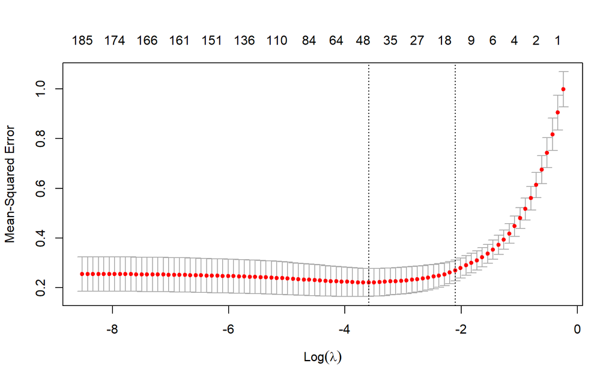

```r
plot(model_Lasso)
```

Plus $\lambda$ augmente, plus la valeur de l’erreur (MSE) augmente. La valeur lambda optimale d’après notre modèle est : 0.1220731 .

*Ridge:*

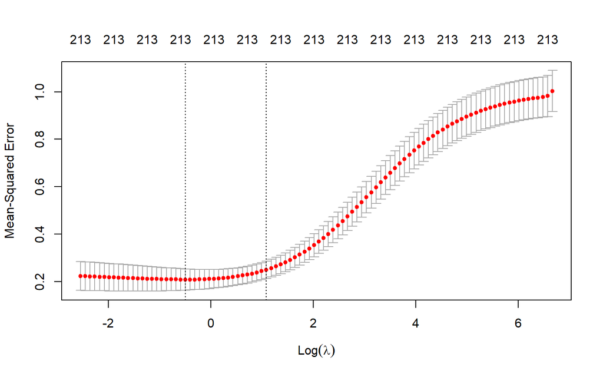

```r
plot(model_Ridge)
```

Plus $\lambda$ augmente, plus la valeur de l’erreur (MSE) augmente. Cependant, comparé au modèle Lasso, l’erreur augmente plus vite dès le debut. Cette différence est dûe au fait que leurs fonctions de coût sont différentes. La valeur lambda optimale d’après notre modèle est : 2.9543257

### 4.7 Evaluation des modèles sur les données de test

```r
predict_lasso <- predict(model_Lasso,as.matrix(X_test))
predict_ridge <- predict(model_Ridge,as.matrix(X_test))
rmse_lasso <- rmse(predict_lasso, y_test)
rmse_ridge <- rmse(predict_ridge, y_test)
```

L’erreur avec le modèle (0.4364709) est plus faible que celle de Lasso (0.4552623) sur un même jeu de données test. Cependant, si on souhaite expliquer le prix des appartements en fonction de peu de variables, on peut se réferer au modèle Lasso. On a vu précédemment que qur 270 variables, le modèle n’en avait gardé que 15, puisque les autres ont des estimateurs pratiquement à zéro.

### Conclusion :

Les régressions Ridge et Lasso sont des techniques de pénalisation qui peuvent être utiles en présence d’un nombre important de variables et lorsqu’il existe des corrélations entre les variables explicatives. Même si toutes deux sont des régularisations, elles diffèrent de par leur fonction de coût (l’une effectue la pénalité L1 et l’autre la L2) ce qui impacte les estimateurs différemment. Pour qu’elles soient utilisées ensemble, il existe des régressions comme l’**elastic Net** qui combinent ces deux méthodes. Ci-dessous un tableau recapitulatif :

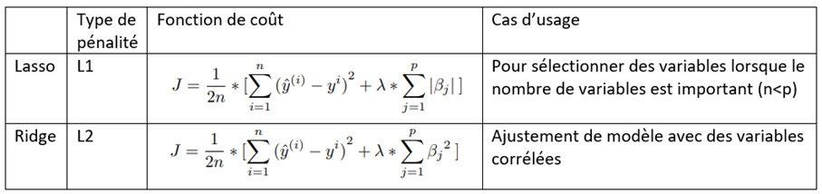